# Untitled

Kehinde Usman

April 10, 2019

## Loading and preprocessing the data

### Load the data file “activity.csv” by using read.csv into Activity Monitoring Data(amd)

```r
    amd <- read.csv("activity.csv", head=TRUE, na.strings="NA")
    str(amd)
```

```
## 'data.frame':    17568 obs. of  3 variables:
##  $ steps   : int  NA NA NA NA NA NA NA NA NA NA ...
##  $ date    : Factor w/ 61 levels "2012-10-01","2012-10-02",..: 1 1 1 1 1 1 1 1 1 1 ...
##  $ interval: int  0 5 10 15 20 25 30 35 40 45 ...
```

### Preprocess the data by converting the data to Year-Month-Day format and ignoring the NA values in steps

```r
amd$date <- as.Date(amd$date)
amd_ignore <- subset(amd, !is.na(amd$steps))
```

## What is mean total number of steps taken per day?

### Calculating the total number of steps taken per day and showing the histogram

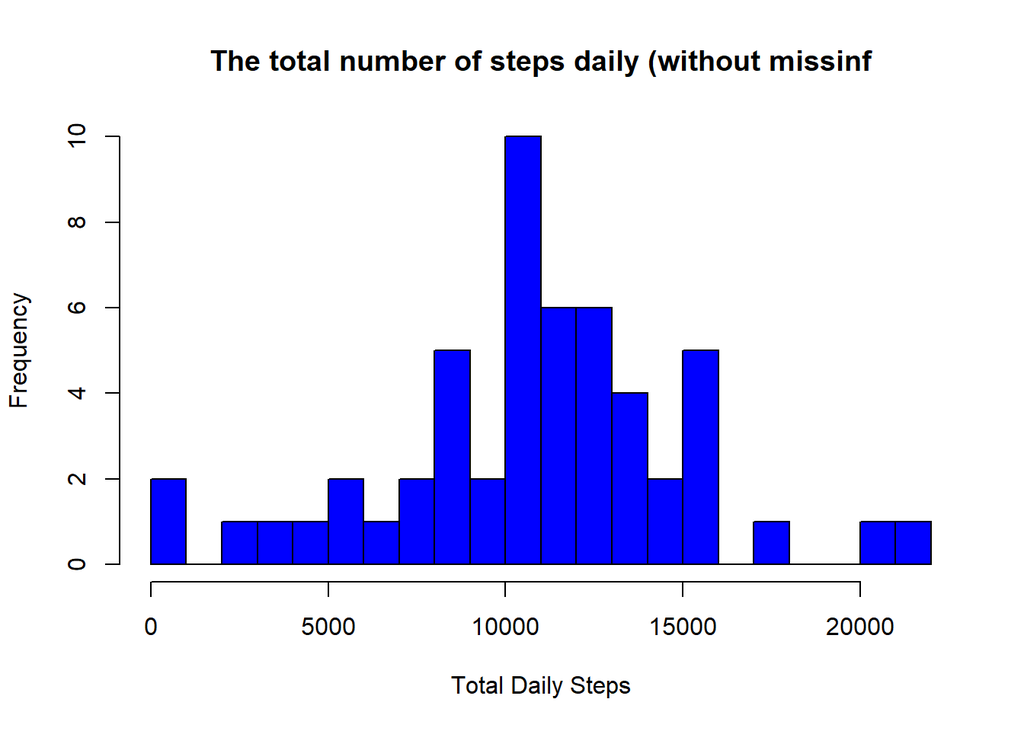

```r
dailystep <- tapply(amd_ignore$steps, amd_ignore$date, sum, na.rm=TRUE)
dailystep <- dailystep[!is.na(dailystep)]

hist(x=dailystep,
     col="blue",
     breaks = 30,
     xlab="Total Daily Steps",
     ylab="Frequency",
     main="The total number of steps daily (without missinf")
```

###Calculate and report the mean and median of the total number of steps taken per day

```r
mean(dailystep)
```

```
## [1] 10766.19
```

```r
median(dailystep)
```

```
## [1] 10765
```

## What is the average daily activity pattern?

### Time series plot of the 5-minutes interval and the average number of steps taken, averaged across all days

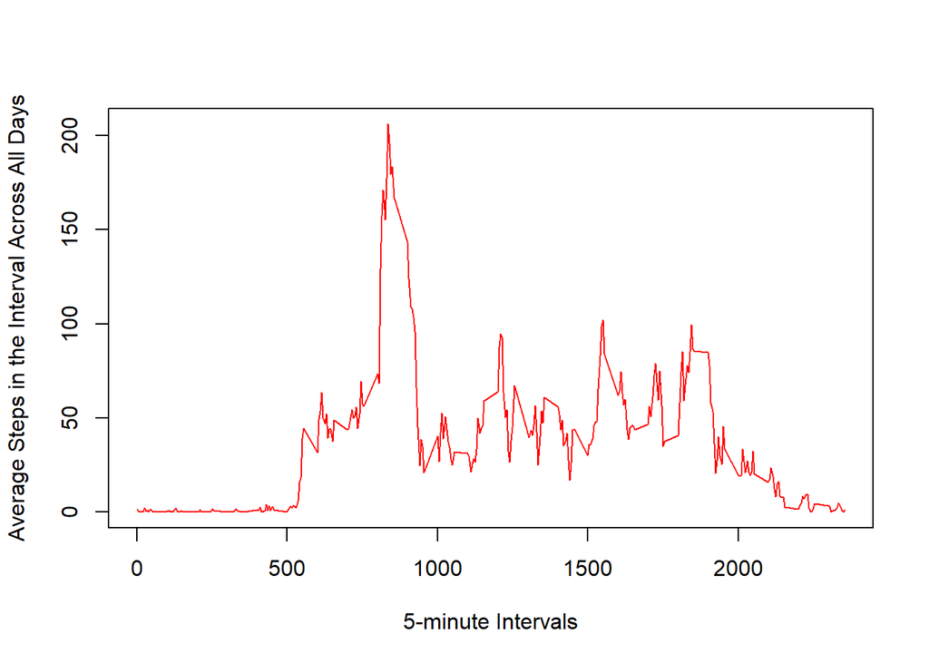

```r
avg_daily <- tapply(amd_ignore$steps, amd_ignore$interval, mean, na.rm=TRUE)
dailyPattern <- data.frame(interval=as.integer(names(avg_daily)), avg=avg_daily)

with(dailyPattern,
     plot(interval,
          avg,
          col="red",
          type="l",
          xlab="5-minute Intervals",
          ylab="Average Steps in the Interval Across All Days"))
```

###The 5-minutes interval that has the maximum number of steps on average across all the days in the dataset.

```r
max_steps <- max(dailyPattern$avg)
dailyPattern[dailyPattern$avg == max_steps, ]
```

```
##     interval      avg
## 835      835 206.1698
```

## Imputing missing values

### The total number of missing values in the dataset

```r
na_number <- sum(is.na(amd$steps))
na_number
```

```
## [1] 2304
```

### Devise a strategy for filling in all of the missing values in the dataset.

### Since the missing values is quite large, therefore we impute missing values based on average number of steps in particular 5-minutes interval.

### A new dataset that is equal to the original dataset but with the missing data filled in

```r
amd_missing <- amd
amd_misssteps <- is.na(amd_missing$steps)
avg_daily <- tapply(amd_ignore$steps, amd_ignore$interval, mean, na.rm=TRUE)
amd_missing$steps[amd_misssteps] <- avg_daily[as.character(amd_missing$interval[amd_misssteps])]
```

### Histogram showing the total number of steps taken each day.

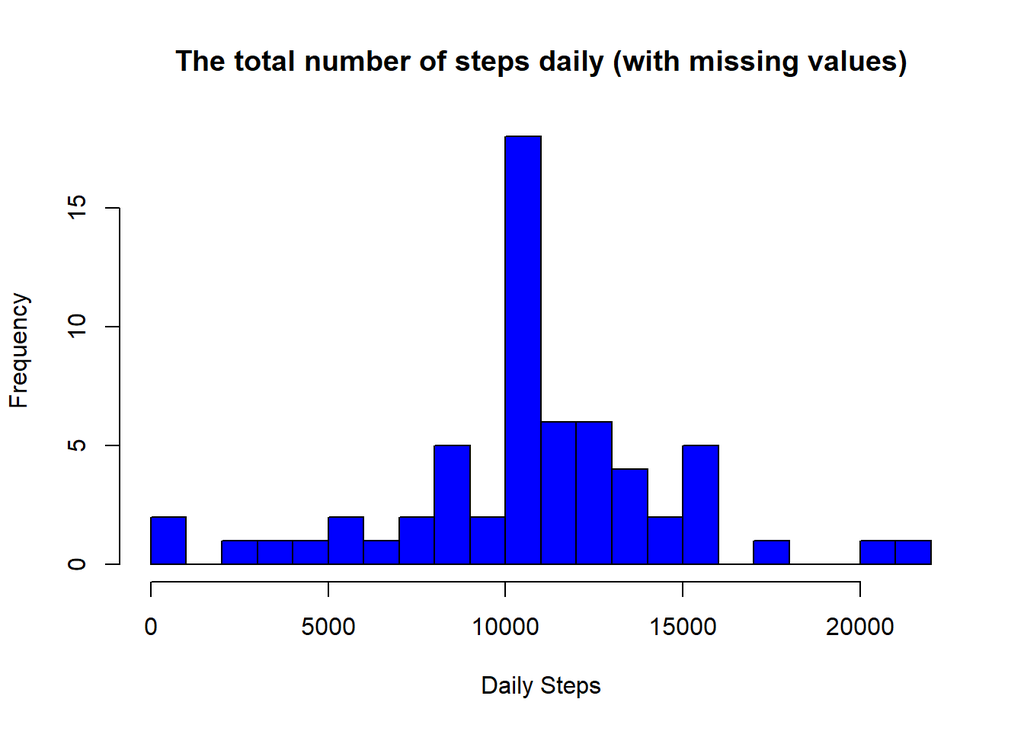

```r
new_dailystep <- tapply(amd_missing$steps, amd_missing$date, sum, na.rm=TRUE)

hist(x=new_dailystep,
     col="blue",
     breaks = 30,
     xlab="Daily Steps",
     ylab="Frequency",
     main="The total number of steps daily (with missing values)")
```

###The mean and median of the total number of steps taken per day

```r
mean(new_dailystep)
```

```
## [1] 10766.19
```

```r
median(new_dailystep)
```

```
## [1] 10766.19
```

### From the first part of the assignment which is total number of steps daily without missing values, the mean values is the same with the imputed data set and the median has a small change.

### One possible explanation is that when we fill the missing data for the intervals, we use means for intervals, so we have more data close or identical to the means, and median is shifted and becomes identical to the mean.

### The impact of imputing missing data on the estimates of the total daily number of steps is also clear: now we have higher frquency counts in the histogram at the center region (close to the mean).